# Ford Gobike Data Exploration

## Preliminary Wrangling

> This data set includes information about individual rides made in a bike-sharing system covering the greater San Francisco Bay area. The aim here is to survey this data, find features of interest, explore them, and come up with conclusion and summary of the findings.

```python
# import all packages and set plots to be embedded inline
import numpy as np
import pandas as pd
import matplotlib.pyplot as plt
import seaborn as sb

%matplotlib inline
```

```python
#In the upcoming couple of cells I will upload the data set, check its structure, understand the data, wrangle it, and point out features of interest
df_bike = pd.read_csv('201902-fordgobike-tripdata.csv')
df_bike.head()
```

|  | duration_sec | start_time | end_time | start_station_id | start_station_name | start_station_latitude | start_station_longitude | end_station_id | end_station_name | end_station_latitude | end_station_longitude | bike_id | user_type | member_birth_year | member_gender | bike_share_for_all_trip |
| --- | --- | --- | --- | --- | --- | --- | --- | --- | --- | --- | --- | --- | --- | --- | --- | --- |
| 0 | 52185 | 2019-02-28 17:32:10.1450 | 2019-03-01 08:01:55.9750 | 21.0 | Montgomery St BART Station (Market St at 2nd St) | 37.789625 | -122.400811 | 13.0 | Commercial St at Montgomery St | 37.794231 | -122.402923 | 4902 | Customer | 1984.0 | Male | No |
| 1 | 42521 | 2019-02-28 18:53:21.7890 | 2019-03-01 06:42:03.0560 | 23.0 | The Embarcadero at Steuart St | 37.791464 | -122.391034 | 81.0 | Berry St at 4th St | 37.775880 | -122.393170 | 2535 | Customer | NaN | NaN | No |
| 2 | 61854 | 2019-02-28 12:13:13.2180 | 2019-03-01 05:24:08.1460 | 86.0 | Market St at Dolores St | 37.769305 | -122.426826 | 3.0 | Powell St BART Station (Market St at 4th St) | 37.786375 | -122.404904 | 5905 | Customer | 1972.0 | Male | No |
| 3 | 36490 | 2019-02-28 17:54:26.0100 | 2019-03-01 04:02:36.8420 | 375.0 | Grove St at Masonic Ave | 37.774836 | -122.446546 | 70.0 | Central Ave at Fell St | 37.773311 | -122.444293 | 6638 | Subscriber | 1989.0 | Other | No |
| 4 | 1585 | 2019-02-28 23:54:18.5490 | 2019-03-01 00:20:44.0740 | 7.0 | Frank H Ogawa Plaza | 37.804562 | -122.271738 | 222.0 | 10th Ave at E 15th St | 37.792714 | -122.248780 | 4898 | Subscriber | 1974.0 | Male | Yes |

##### From the visual assessment several issues is highlighted that requires wrangling:

> 1- The start_time and end_time can be separated to four columns two related to the time and two related to the date.  
> 2- Some date type for some columns are not correct. For example, the station id (start and end) are floats instead of being strings. They are categorical type not numirical. Also, the values under the column member_birth_year are shown as floats instead of being integers.  
> 3- Some missing values (NaN) or unregonized values are shown such as "Other" under gender variable.  
> All those highlighted issues needs to be cleaned in order to proveed and avoid any issues during ploting and visalization stage.

```python
#first separating start_time and end_time each to two columns
#Copy the original dataframe
df_copy = df_bike.copy()
df_copy[['start_date','start_time']] = df_copy.start_time.str.split(" ",expand=True)
df_copy[['end_date','end_time']] = df_copy.end_time.str.split(" ",expand=True)
df_copy.head()
```

|  | duration_sec | start_time | end_time | start_station_id | start_station_name | start_station_latitude | start_station_longitude | end_station_id | end_station_name | end_station_latitude | end_station_longitude | bike_id | user_type | member_birth_year | member_gender | bike_share_for_all_trip | start_date | end_date |
| --- | --- | --- | --- | --- | --- | --- | --- | --- | --- | --- | --- | --- | --- | --- | --- | --- | --- | --- |
| 0 | 52185 | 17:32:10.1450 | 08:01:55.9750 | 21.0 | Montgomery St BART Station (Market St at 2nd St) | 37.789625 | -122.400811 | 13.0 | Commercial St at Montgomery St | 37.794231 | -122.402923 | 4902 | Customer | 1984.0 | Male | No | 2019-02-28 | 2019-03-01 |
| 1 | 42521 | 18:53:21.7890 | 06:42:03.0560 | 23.0 | The Embarcadero at Steuart St | 37.791464 | -122.391034 | 81.0 | Berry St at 4th St | 37.775880 | -122.393170 | 2535 | Customer | NaN | NaN | No | 2019-02-28 | 2019-03-01 |
| 2 | 61854 | 12:13:13.2180 | 05:24:08.1460 | 86.0 | Market St at Dolores St | 37.769305 | -122.426826 | 3.0 | Powell St BART Station (Market St at 4th St) | 37.786375 | -122.404904 | 5905 | Customer | 1972.0 | Male | No | 2019-02-28 | 2019-03-01 |
| 3 | 36490 | 17:54:26.0100 | 04:02:36.8420 | 375.0 | Grove St at Masonic Ave | 37.774836 | -122.446546 | 70.0 | Central Ave at Fell St | 37.773311 | -122.444293 | 6638 | Subscriber | 1989.0 | Other | No | 2019-02-28 | 2019-03-01 |
| 4 | 1585 | 23:54:18.5490 | 00:20:44.0740 | 7.0 | Frank H Ogawa Plaza | 37.804562 | -122.271738 | 222.0 | 10th Ave at E 15th St | 37.792714 | -122.248780 | 4898 | Subscriber | 1974.0 | Male | Yes | 2019-02-28 | 2019-03-01 |

```python
df_copy.columns
column_names = ['duration_sec', 'start_date', 'start_time', 'end_date', 'end_time', 'start_station_id',
       'start_station_name', 'start_station_latitude',
       'start_station_longitude', 'end_station_id', 'end_station_name',
       'end_station_latitude', 'end_station_longitude', 'bike_id', 'user_type',
       'member_birth_year', 'member_gender', 'bike_share_for_all_trip']
df_copy = df_copy.reindex(columns=column_names)
df_copy.head()
```

|  | duration_sec | start_date | start_time | end_date | end_time | start_station_id | start_station_name | start_station_latitude | start_station_longitude | end_station_id | end_station_name | end_station_latitude | end_station_longitude | bike_id | user_type | member_birth_year | member_gender | bike_share_for_all_trip |
| --- | --- | --- | --- | --- | --- | --- | --- | --- | --- | --- | --- | --- | --- | --- | --- | --- | --- | --- |
| 0 | 52185 | 2019-02-28 | 17:32:10.1450 | 2019-03-01 | 08:01:55.9750 | 21.0 | Montgomery St BART Station (Market St at 2nd St) | 37.789625 | -122.400811 | 13.0 | Commercial St at Montgomery St | 37.794231 | -122.402923 | 4902 | Customer | 1984.0 | Male | No |
| 1 | 42521 | 2019-02-28 | 18:53:21.7890 | 2019-03-01 | 06:42:03.0560 | 23.0 | The Embarcadero at Steuart St | 37.791464 | -122.391034 | 81.0 | Berry St at 4th St | 37.775880 | -122.393170 | 2535 | Customer | NaN | NaN | No |
| 2 | 61854 | 2019-02-28 | 12:13:13.2180 | 2019-03-01 | 05:24:08.1460 | 86.0 | Market St at Dolores St | 37.769305 | -122.426826 | 3.0 | Powell St BART Station (Market St at 4th St) | 37.786375 | -122.404904 | 5905 | Customer | 1972.0 | Male | No |
| 3 | 36490 | 2019-02-28 | 17:54:26.0100 | 2019-03-01 | 04:02:36.8420 | 375.0 | Grove St at Masonic Ave | 37.774836 | -122.446546 | 70.0 | Central Ave at Fell St | 37.773311 | -122.444293 | 6638 | Subscriber | 1989.0 | Other | No |
| 4 | 1585 | 2019-02-28 | 23:54:18.5490 | 2019-03-01 | 00:20:44.0740 | 7.0 | Frank H Ogawa Plaza | 37.804562 | -122.271738 | 222.0 | 10th Ave at E 15th St | 37.792714 | -122.248780 | 4898 | Subscriber | 1974.0 | Male | Yes |

```python
#inspecting data types for df_copy
df_copy.info()
```

```
<class 'pandas.core.frame.DataFrame'>
RangeIndex: 183412 entries, 0 to 183411
Data columns (total 18 columns):
 #   Column                   Non-Null Count   Dtype
---  ------                   --------------   -----
 0   duration_sec             183412 non-null  int64
 1   start_date               183412 non-null  object
 2   start_time               183412 non-null  object
 3   end_date                 183412 non-null  object
 4   end_time                 183412 non-null  object
 5   start_station_id         183215 non-null  float64
 6   start_station_name       183215 non-null  object
 7   start_station_latitude   183412 non-null  float64
 8   start_station_longitude  183412 non-null  float64
 9   end_station_id           183215 non-null  float64
 10  end_station_name         183215 non-null  object
 11  end_station_latitude     183412 non-null  float64
 12  end_station_longitude    183412 non-null  float64
 13  bike_id                  183412 non-null  int64
 14  user_type                183412 non-null  object
 15  member_birth_year        175147 non-null  float64
 16  member_gender            175147 non-null  object
 17  bike_share_for_all_trip  183412 non-null  object
dtypes: float64(7), int64(2), object(9)
memory usage: 25.2+ MB
```

```python
df_copy2 = df_copy.dropna()
df_copy2.info()
```

```
<class 'pandas.core.frame.DataFrame'>
Int64Index: 174952 entries, 0 to 183411
Data columns (total 18 columns):
 #   Column                   Non-Null Count   Dtype
---  ------                   --------------   -----
 0   duration_sec             174952 non-null  int64
 1   start_date               174952 non-null  object
 2   start_time               174952 non-null  object
 3   end_date                 174952 non-null  object
 4   end_time                 174952 non-null  object
 5   start_station_id         174952 non-null  float64
 6   start_station_name       174952 non-null  object
 7   start_station_latitude   174952 non-null  float64
 8   start_station_longitude  174952 non-null  float64
 9   end_station_id           174952 non-null  float64
 10  end_station_name         174952 non-null  object
 11  end_station_latitude     174952 non-null  float64
 12  end_station_longitude    174952 non-null  float64
 13  bike_id                  174952 non-null  int64
 14  user_type                174952 non-null  object
 15  member_birth_year        174952 non-null  float64
 16  member_gender            174952 non-null  object
 17  bike_share_for_all_trip  174952 non-null  object
dtypes: float64(7), int64(2), object(9)
memory usage: 25.4+ MB
```

**The following columns have the wrong type assigned to them: [start_date, start_time, end_date, end_time, start_station_id, end_station_id, bike_id, member_birth_year]**

```python
#converting columns types
convert_dict = {'start_station_id': str,
                'end_station_id': str,
                'bike_id': str,
                'member_birth_year': int
               }

df_copy2 = df_copy2.astype(convert_dict)
```

```python
df_copy2['start_date'] = pd.to_datetime(df_copy2['start_date'])
df_copy2['start_time'] = pd.to_datetime(df_copy2['start_time'])
df_copy2['end_date'] = pd.to_datetime(df_copy2['end_date'])
df_copy2['end_time'] = pd.to_datetime(df_copy2['end_time'])
```

```python
df_copy2.info()
```

```
<class 'pandas.core.frame.DataFrame'>
Int64Index: 174952 entries, 0 to 183411
Data columns (total 18 columns):
 #   Column                   Non-Null Count   Dtype
---  ------                   --------------   -----
 0   duration_sec             174952 non-null  int64
 1   start_date               174952 non-null  datetime64[ns]
 2   start_time               174952 non-null  datetime64[ns]
 3   end_date                 174952 non-null  datetime64[ns]
 4   end_time                 174952 non-null  datetime64[ns]
 5   start_station_id         174952 non-null  object
 6   start_station_name       174952 non-null  object
 7   start_station_latitude   174952 non-null  float64
 8   start_station_longitude  174952 non-null  float64
 9   end_station_id           174952 non-null  object
 10  end_station_name         174952 non-null  object
 11  end_station_latitude     174952 non-null  float64
 12  end_station_longitude    174952 non-null  float64
 13  bike_id                  174952 non-null  object
 14  user_type                174952 non-null  object
 15  member_birth_year        174952 non-null  int32
 16  member_gender            174952 non-null  object
 17  bike_share_for_all_trip  174952 non-null  object
dtypes: datetime64[ns](4), float64(4), int32(1), int64(1), object(8)
memory usage: 24.7+ MB
```

**Additional change is to convert the duration columns from being in seconds to be in minutes by dividing the values by 60**

```python
df_clean = df_copy2.copy()
df_clean['duration_sec'] = df_clean['duration_sec']/60
df_clean.rename(columns={'duration_sec': 'duration_min'}, inplace = True)
df_clean.info()
```

```
<class 'pandas.core.frame.DataFrame'>
Int64Index: 174952 entries, 0 to 183411
Data columns (total 18 columns):
 #   Column                   Non-Null Count   Dtype
---  ------                   --------------   -----
 0   duration_min             174952 non-null  float64
 1   start_date               174952 non-null  datetime64[ns]
 2   start_time               174952 non-null  datetime64[ns]
 3   end_date                 174952 non-null  datetime64[ns]
 4   end_time                 174952 non-null  datetime64[ns]
 5   start_station_id         174952 non-null  object
 6   start_station_name       174952 non-null  object
 7   start_station_latitude   174952 non-null  float64
 8   start_station_longitude  174952 non-null  float64
 9   end_station_id           174952 non-null  object
 10  end_station_name         174952 non-null  object
 11  end_station_latitude     174952 non-null  float64
 12  end_station_longitude    174952 non-null  float64
 13  bike_id                  174952 non-null  object
 14  user_type                174952 non-null  object
 15  member_birth_year        174952 non-null  int32
 16  member_gender            174952 non-null  object
 17  bike_share_for_all_trip  174952 non-null  object
dtypes: datetime64[ns](4), float64(5), int32(1), object(8)
memory usage: 24.7+ MB
```

### What is the structure of your dataset?

> The data set consists of 18 columns & 174952 entries (after cleaning and missing values). All data types are corrected as shown above.

### What is/are the main feature(s) of interest in your dataset?

> The main feature of interest is the **user_type** and its relation with duration, members birth, and gneder.

### What features in the dataset do you think will help support your investigation into your feature(s) of interest?

> The features that will support the investigation are [duration_min, member_birth_year, member_gender]

## Univariate Exploration

```python
#without_hue function will plot percentages on the bar graphs if you have a normal plot.
#It takes the actual graph and feature as a parameter.
def without_hue(plot, feature):
    total = len(feature)
    for p in plot.patches:
        percentage = '{:.1f}%'.format(100 * p.get_height()/total)
        x = p.get_x() + p.get_width() / 2 - 0.05
        y = p.get_y() + p.get_height()
        ax.annotate(percentage, (x, y), size = 12)
    plt.show()
```

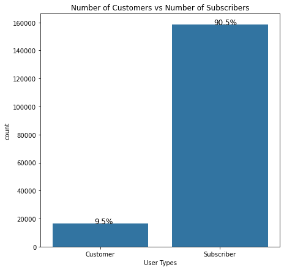

```python
plt.figure(figsize=(7,7))
plt.title('Number of Customers vs Number of Subscribers')
ax = sb.countplot(data = df_clean, x = 'user_type', color = sb.color_palette()[0]);
ax.set_xlabel('User Types')
without_hue(ax, df_clean.user_type)
```

**From the first plot it can be seen that most of the user types are subscriber (almost 91%) against only 9% which are customers**

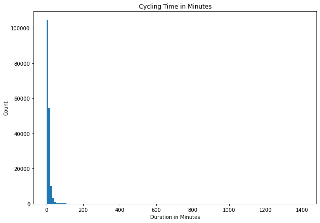

```python
plt.figure(figsize=(10,7));
plt.title('Cycling Time in Minutes');
bins = np.arange(0, df_clean['duration_min'].max()+10, 10);
plt.hist(data = df_clean, x = 'duration_min', bins = bins);
plt.xlabel('Duration in Minutes');
plt.ylabel('Count');
```

*Since the above histogram is skewed, it needs to be scaled using log scale in order to change it to normal distribution*

```python
des = df_clean['duration_min'].describe()
f= np.log10(des)
```

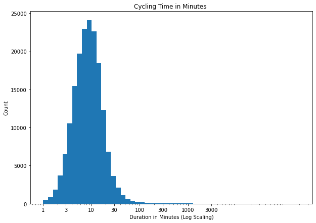

```python
plt.figure(figsize=(10,7))
binss = 10**np.arange(f.min(), f.max()+0.1, 0.1)
plt.title('Cycling Time in Minutes ')
plt.hist(data = df_clean, x = 'duration_min', bins = binss);
plt.xscale('log');
ticks= [1, 3, 10, 30, 100, 300, 1000, 3000]
labels = ['{}'.format(v) for v in ticks]
plt.xticks(ticks, labels);
plt.xlabel('Duration in Minutes (Log Scaling)');
plt.ylabel('Count');
```

**From the second plot it can be seen that duration destribution is normally destributed (after using the log scaling). Moreover, it seems that most of the user are utilizing the bikes for a period of 3 to 30 minutes. this can be an indicator that it is mostly used for sport and short picnic**

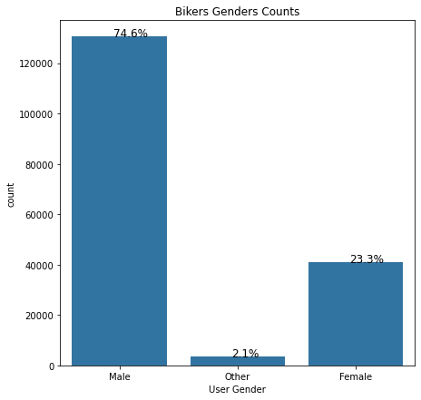

```python
plt.figure(figsize=(7,7))
plt.title('Bikers Genders Counts')
ax = sb.countplot(data = df_clean, x = 'member_gender', color = sb.color_palette()[0]);
ax.set_xlabel('User Gender')
without_hue(ax, df_clean.member_gender)
```

**From the third plot it is clear that most of the users are males and they make around 75% of the bike users, while the female users are 23%. The remaining 2% represents those who either chose not to identify their gender or indentified themselves as *Others***

```python
df_clean['member_birth_year'].describe()
```

```
count    174952.000000
mean       1984.803135
std          10.118731
min        1878.000000
25%        1980.000000
50%        1987.000000
75%        1992.000000
max        2001.000000
Name: member_birth_year, dtype: float64
```

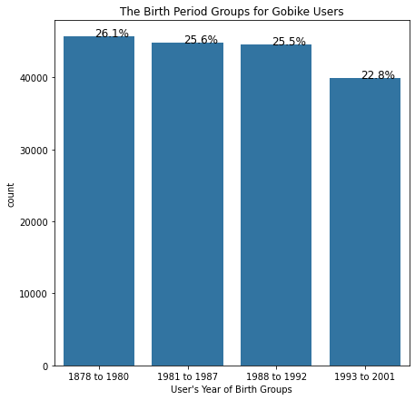

```python
df_clean['age_groups'] = pd.cut(df_clean['member_birth_year'], bins = [1878, 1980, 1987, 1992, 2001],
                                labels=['1878 to 1980', '1981 to 1987', '1988 to 1992','1993 to 2001'])
plt.figure(figsize=(7,7))
plt.title('The Birth Period Groups for Gobike Users')
ax = sb.countplot(data = df_clean, x = 'age_groups', color = sb.color_palette()[0]);
ax.set_xlabel("User's Year of Birth Groups")
without_hue(ax, df_clean.age_groups);
```

**From the above chart for age_groups it can be seen that customers age groups are almost equal. However, the highest number of users group is the the ones born between 1878 and 1980. This may explain the reason why most users are using the bikes for short periods 10 minutes on average. It might be for excersizing**

### Of the features you investigated, were there any unusual distributions? Did you perform any operations on the data to tidy, adjust, or change the form of the data? If so, why did you do this?

> As mentioned in the previous question, the duration im minutes histogram plot, is orginally highly skewed to the right & can't be interprated. Therefore, I used the log scale to change this skewed histogram to normally distributed ones that gives clearer image for what is going on. It was found out that most of the users spend 10 minutes in riding the bikes on average.

## Bivariate Exploration

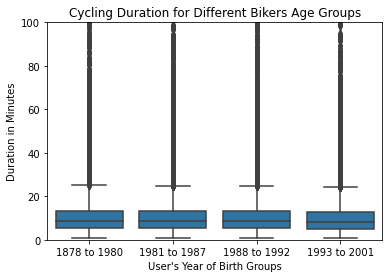

```python
plt.title('Cycling Duration for Different Bikers Age Groups')
sb.boxplot(data = df_clean, x = 'age_groups', y = 'duration_min', color = sb.color_palette()[0])
plt.ylim((0, 100))
plt.xlabel("User's Year of Birth Groups")
plt.ylabel('Duration in Minutes');
```

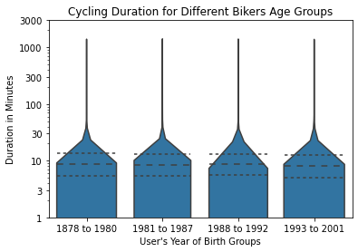

```python
plt.title('Cycling Duration for Different Bikers Age Groups')
sb.violinplot(data = df_clean, x = 'age_groups', y = 'duration_min', color = sb.color_palette()[0], bins =binss, inner = 'quartile')
plt.yscale('log')
ticks= [1, 3, 10, 30, 100, 300, 1000, 3000]
labels = ['{}'.format(v) for v in ticks]
plt.yticks(ticks, labels);
plt.xlabel("User's Year of Birth Groups")
plt.ylabel('Duration in Minutes');
```

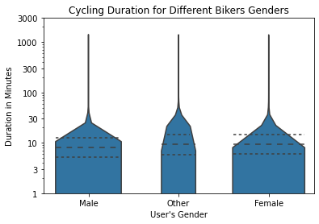

```python
plt.title('Cycling Duration for Different Bikers Genders')
sb.violinplot(data = df_clean, x = 'member_gender', y = 'duration_min', color = sb.color_palette()[0], bins =binss, inner = 'quartile');
plt.yscale('log')
ticks= [1, 3, 10, 30, 100, 300, 1000, 3000]
labels = ['{}'.format(v) for v in ticks]
plt.yticks(ticks, labels);
plt.xlabel("User's Gender")
plt.ylabel('Duration in Minutes');
```

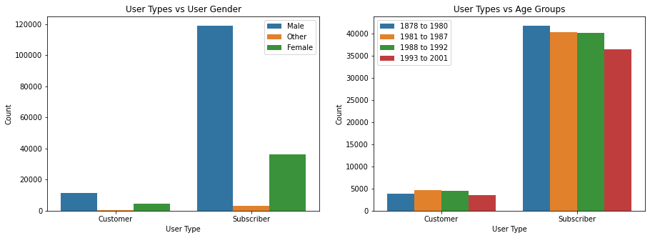

```python
plt.figure(figsize = (15, 5))

plt.subplot(1, 2, 1)
plt.title('User Types vs User Gender')
sb.countplot(data = df_clean, x = 'user_type', hue = 'member_gender')
plt.xlabel("User Type")
plt.ylabel('Count')
plt.legend()

plt.subplot(1, 2, 2)
plt.title('User Types vs Age Groups')
sb.countplot(data = df_clean, x = 'user_type', hue = 'age_groups')
plt.xlabel("User Type")
plt.ylabel('Count')
plt.legend();
```

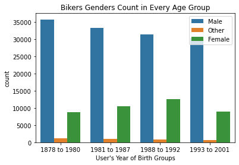

```python
plt.title('Bikers Genders Count in Every Age Group')
sb.countplot(data = df_clean, x = 'age_groups', hue = 'member_gender')
plt.xlabel("User's Year of Birth Groups")
plt.legend();
```

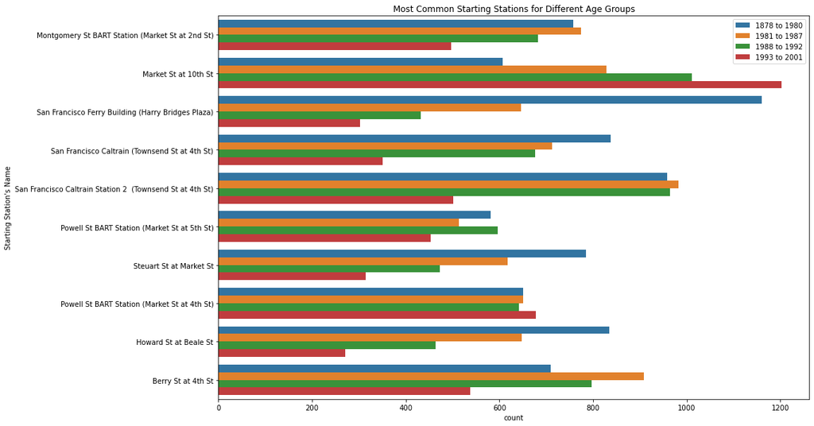

```python
A = df_clean['start_station_id'].value_counts()[:10]
A.reset_index()
List = ['{}'.format(i) for i in A.index]
df_common_start = df_clean.loc[df_clean['start_station_id'].isin(List)]
plt.figure(figsize = (15, 10))
plt.title("Most Common Starting Stations for Different Age Groups")
sb.countplot(data = df_common_start, y = 'start_station_name', hue = 'age_groups')
plt.ylabel("Starting Station's Name")
plt.legend();
```

### Talk about some of the relationships you observed in this part of the investigation. How did the feature(s) of interest vary with other features in the dataset?

> 1- Even though most of the users are subscribers, and customers user types are only 9%, it was found that most of the customers types' birth years fall in the range of 1981 to 1987. While most of the subscribers birth years fall in the group of 1878 to 1980.  
> 2- It was found that all users are utilizing the bikes 10 minutes on average regardles of their age or gender.  
> 3- The intersting fact is that, most of the male users are in the birth group of (1878 - 1980) and lowest are in the group of (1993 - 2001). While most of the female users are in the birth group of (1988 - 1992) and lowest are in the group of (1878 - 1980).

## Multivariate Exploration

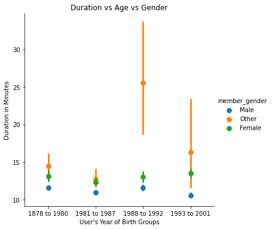

```python
#plt.figure(figsize = (15, 10))
sb.factorplot(x = 'age_groups', y = 'duration_min', hue = 'member_gender', data = df_clean, linestyles = "");
plt.title("Duration vs Age vs Gender");
plt.xlabel("User's Year of Birth Groups")
plt.ylabel("Duration in Minutes");
```

### Talk about some of the relationships you observed in this part of the investigation. Were there features that strengthened each other in terms of looking at your feature(s) of interest?

> The previously stated observation that the avarage duration is almost the same across all groups of ages is being confirmed in the above multivariate chart.  
> The same can "almost" be stated about the genders at least for the females and males.

### Were there any interesting or surprising interactions between features?

> There is one main intersting observation that was not revealed during the Bivariate exploartion, which is between genders and duration spent using the bike. This observation is that the people who identified themselves as others (not male nor female)are spending far more time riding the bikes espcially for those who were born in the period between 1988 and 1992, followed by those who were born between 1993 and 2001